# Cereals Data

**Extra Assignement2**

https://i.ytimg.com/vi/re0B-VuDc6o/maxresdefault.jpg

Content Fields in the dataset: • Name: Name of cereal • mfr: Manufacturer of cereal ○ A = American Home Food Products; ○ G = General Mills ○ K = Kelloggs ○ N = Nabisco ○ P = Post ○ Q = Quaker Oats ○ R = Ralston Purina • type: ○ c: cold ○ h: hot • calories: calories per serving • protein: grams of protein • fat: grams of fat • sodium: milligrams of sodium • fiber: grams of dietary fiber • carbo: grams of complex carbohydrates • sugars: grams of sugars • potass: milligrams of potassium • vitamins: vitamins and minerals - 0, 25, or 100, indicating the typical percentage of FDA recommended • shelf: display shelf (1, 2, or 3, counting from the floor) • weight: weight in ounces of one serving • cups: number of cups in one serving • rating: a rating of the cereals (Possibly from Consumer Reports?)

## Importing and Cleaning Data

## Import Data

We will use the tidyverse library for importing and wrangling the data.

| name | mfr | type | calories | protein | fat | sodium | fiber | carbo | sugars | potass | vitamins | shelf | weight | cups | rating |
| --- | --- | --- | --- | --- | --- | --- | --- | --- | --- | --- | --- | --- | --- | --- | --- |
| 100% Bran | N | C | 70 | 4 | 1 | 130 | 10.0 | 5.0 | 6 | 280 | 25 | 3 | 1.00 | 0.33 | 68.40297 |
| 100% Natural Bran | Q | C | 120 | 3 | 5 | 15 | 2.0 | 8.0 | 8 | 135 | 0 | 3 | 1.00 | 1.00 | 33.98368 |
| All-Bran | K | C | 70 | 4 | 1 | 260 | 9.0 | 7.0 | 5 | 320 | 25 | 3 | 1.00 | 0.33 | 59.42551 |
| All-Bran with Extra Fiber | K | C | 50 | 4 | 0 | 140 | 14.0 | 8.0 | 0 | 330 | 25 | 3 | 1.00 | 0.50 | 93.70491 |
| Almond Delight | R | C | 110 | 2 | 2 | 200 | 1.0 | 14.0 | 8 | -1 | 25 | 3 | 1.00 | 0.75 | 34.38484 |
| Apple Cinnamon Cheerios | G | C | 110 | 2 | 2 | 180 | 1.5 | 10.5 | 10 | 70 | 25 | 1 | 1.00 | 0.75 | 29.50954 |
| Apple Jacks | K | C | 110 | 2 | 0 | 125 | 1.0 | 11.0 | 14 | 30 | 25 | 2 | 1.00 | 1.00 | 33.17409 |
| Basic 4 | G | C | 130 | 3 | 2 | 210 | 2.0 | 18.0 | 8 | 100 | 25 | 3 | 1.33 | 0.75 | 37.03856 |
| Bran Chex | R | C | 90 | 2 | 1 | 200 | 4.0 | 15.0 | 6 | 125 | 25 | 1 | 1.00 | 0.67 | 49.12025 |
| Bran Flakes | P | C | 90 | 3 | 0 | 210 | 5.0 | 13.0 | 5 | 190 | 25 | 3 | 1.00 | 0.67 | 53.31381 |

[output cut: 67 more lines]

## Data Cleaning and Wrangling

|  | name | mfr | type | calories | protein | fat | sodium | fiber | carbo | sugars | potass | vitamins | shelf | weight | cups | rating |
| --- | --- | --- | --- | --- | --- | --- | --- | --- | --- | --- | --- | --- | --- | --- | --- | --- |
| 1 | 100% Bran | N | C | 70 | 4 | 1 | 130 | 10.0 | 5.0 | 6 | 280 | 25 | 3 | 1 | 0.33 | 68.40297 |
| 2 | 100% Natural Bran | Q | C | 120 | 3 | 5 | 15 | 2.0 | 8.0 | 8 | 135 | 0 | 3 | 1 | 1.00 | 33.98368 |
| 3 | All-Bran | K | C | 70 | 4 | 1 | 260 | 9.0 | 7.0 | 5 | 320 | 25 | 3 | 1 | 0.33 | 59.42551 |
| 4 | All-Bran with Extra Fiber | K | C | 50 | 4 | 0 | 140 | 14.0 | 8.0 | 0 | 330 | 25 | 3 | 1 | 0.50 | 93.70491 |
| 5 | Almond Delight | R | C | 110 | 2 | 2 | 200 | 1.0 | 14.0 | 8 | -1 | 25 | 3 | 1 | 0.75 | 34.38484 |
| 6 | Apple Cinnamon Cheerios | G | C | 110 | 2 | 2 | 180 | 1.5 | 10.5 | 10 | 70 | 25 | 1 | 1 | 0.75 | 29.50954 |

|  | Name | Manufacturer | Type | Calories | Protein | Fat | Sodium | Fibre | Carbohydrates | Sugar | Potassium | Vitamins | Shelf | Weight | Cups | Rating |
| --- | --- | --- | --- | --- | --- | --- | --- | --- | --- | --- | --- | --- | --- | --- | --- | --- |
| 1 | 100% Bran | N | C | 70 | 4 | 1 | 130 | 10.0 | 5.0 | 6 | 280 | 25 | 3 | 1 | 0.33 | 68.40297 |
| 2 | 100% Natural Bran | Q | C | 120 | 3 | 5 | 15 | 2.0 | 8.0 | 8 | 135 | 0 | 3 | 1 | 1.00 | 33.98368 |
| 3 | All-Bran | K | C | 70 | 4 | 1 | 260 | 9.0 | 7.0 | 5 | 320 | 25 | 3 | 1 | 0.33 | 59.42551 |
| 4 | All-Bran with Extra Fiber | K | C | 50 | 4 | 0 | 140 | 14.0 | 8.0 | 0 | 330 | 25 | 3 | 1 | 0.50 | 93.70491 |
| 5 | Almond Delight | R | C | 110 | 2 | 2 | 200 | 1.0 | 14.0 | 8 | -1 | 25 | 3 | 1 | 0.75 | 34.38484 |
| 6 | Apple Cinnamon Cheerios | G | C | 110 | 2 | 2 | 180 | 1.5 | 10.5 | 10 | 70 | 25 | 1 | 1 | 0.75 | 29.50954 |

• mfr: Manufacturer of cereal ○ A = American Home Food Products; ○ G = General Mills ○ K = Kelloggs ○ N = Nabisco ○ P = Post ○ Q = Quaker Oats ○ R = Ralston Purina

# Create feature with full manufacturer name

```r
cereals_data$Manufacturer_Name
```

```
 [1] "Nabisco"                        "Quaker Oats"                    "Kelloggs"
 [4] "Kelloggs"                       "Ralston Purina"                 "General Mills"
 [7] "Kelloggs"                       "General Mills"                  "Ralston Purina"
[10] "Post"                           "Quaker Oats"                    "General Mills"
[13] "General Mills"                  "General Mills"                  "General Mills"
[16] "Ralston Purina"                 "Kelloggs"                       "Kelloggs"
[19] "General Mills"                  "Kelloggs"                       "Nabisco"
[22] "Kelloggs"                       "General Mills"                  "Ralston Purina"
[25] "Kelloggs"                       "Kelloggs"                       "Kelloggs"
[28] "Post"                           "Kelloggs"                       "Post"
[31] "Post"                           "General Mills"                  "Post"
[34] "Post"                           "Post"                           "Quaker Oats"
[37] "General Mills"                  "Post"                           "Kelloggs"
[40] "Kelloggs"                       "General Mills"                  "Quaker Oats"
[43] "General Mills"                  "American Home Food Postroducts" "Ralston Purina"
[46] "Ralston Purina"                 "Kelloggs"                       "General Mills"
[49] "Kelloggs"                       "Kelloggs"                       "Kelloggs"
[52] "General Mills"                  "Post"                           "Kelloggs"
[55] "Quaker Oats"                    "Quaker Oats"                    "Quaker Oats"
[58] "Quaker Oats"                    "Kelloggs"                       "General Mills"
[61] "Kelloggs"                       "Ralston Purina"                 "Kelloggs"
[64] "Nabisco"                        "Nabisco"                        "Nabisco"
[67] "Kelloggs"                       "Kelloggs"                       "Nabisco"
[70] "General Mills"                  "General Mills"                  "General Mills"
[73] "General Mills"                  "General Mills"                  "Ralston Purina"
[76] "General Mills"                  "General Mills"
```

# Replace H and C in Type with Hot and Cold

• type: ○ c: cold ○ h: hot

```r
cereals_data$Type <- gsub("H", "Hot", x = cereals_data$Type)
cereals_data$Type <- gsub("C", "Cold", x = cereals_data$Type)
```

# Change cereal type and shelf from character to factor

```r
summary(cereals_data)# summary
```

```
                        Name    Manufacturer   Type       Calories        Protein           Fat
 100% Bran                : 1   A: 1         Cold:74   Min.   : 50.0   Min.   :1.000   Min.   :0.000
 100% Natural Bran        : 1   G:22         Hot : 3   1st Qu.:100.0   1st Qu.:2.000   1st Qu.:0.000
 All-Bran                 : 1   K:23                   Median :110.0   Median :3.000   Median :1.000
 All-Bran with Extra Fiber: 1   N: 6                   Mean   :106.9   Mean   :2.545   Mean   :1.013
 Almond Delight           : 1   P: 9                   3rd Qu.:110.0   3rd Qu.:3.000   3rd Qu.:2.000
 Apple Cinnamon Cheerios  : 1   Q: 8                   Max.   :160.0   Max.   :6.000   Max.   :5.000
 (Other)                  :71   R: 8
     Sodium          Fibre        Carbohydrates      Sugar          Potassium         Vitamins      Shelf
 Min.   :  0.0   Min.   : 0.000   Min.   :-1.0   Min.   :-1.000   Min.   : -1.00   Min.   :  0.00   1:20
 1st Qu.:130.0   1st Qu.: 1.000   1st Qu.:12.0   1st Qu.: 3.000   1st Qu.: 40.00   1st Qu.: 25.00   2:21
 Median :180.0   Median : 2.000   Median :14.0   Median : 7.000   Median : 90.00   Median : 25.00   3:36
 Mean   :159.7   Mean   : 2.152   Mean   :14.6   Mean   : 6.922   Mean   : 96.08   Mean   : 28.25
 3rd Qu.:210.0   3rd Qu.: 3.000   3rd Qu.:17.0   3rd Qu.:11.000   3rd Qu.:120.00   3rd Qu.: 25.00
 Max.   :320.0   Max.   :14.000   Max.   :23.0   Max.   :15.000   Max.   :330.00   Max.   :100.00

     Weight          Cups           Rating      Manufacturer_Name
 Min.   :0.50   Min.   :0.250   Min.   :18.04   Length:77
 1st Qu.:1.00   1st Qu.:0.670   1st Qu.:33.17   Class :character
 Median :1.00   Median :0.750   Median :40.40   Mode  :character
 Mean   :1.03   Mean   :0.821   Mean   :42.67
 3rd Qu.:1.00   3rd Qu.:1.000   3rd Qu.:50.83
 Max.   :1.50   Max.   :1.500   Max.   :93.70
```

**Carbohydrates, sugars and Potassium have some negative values. Since this is not possible we can replace negative values with NA.**

# Replace negative values with NA

```r
summary(cereals_data)
```

```
                        Name    Manufacturer   Type       Calories        Protein           Fat
 100% Bran                : 1   A: 1         Cold:74   Min.   : 50.0   Min.   :1.000   Min.   :0.000
 100% Natural Bran        : 1   G:22         Hot : 3   1st Qu.:100.0   1st Qu.:2.000   1st Qu.:0.000
 All-Bran                 : 1   K:23                   Median :110.0   Median :3.000   Median :1.000
 All-Bran with Extra Fiber: 1   N: 6                   Mean   :106.9   Mean   :2.545   Mean   :1.013
 Almond Delight           : 1   P: 9                   3rd Qu.:110.0   3rd Qu.:3.000   3rd Qu.:2.000
 Apple Cinnamon Cheerios  : 1   Q: 8                   Max.   :160.0   Max.   :6.000   Max.   :5.000
 (Other)                  :71   R: 8
     Sodium          Fibre        Carbohydrates      Sugar          Potassium         Vitamins      Shelf
 Min.   :  0.0   Min.   : 0.000   Min.   : 5.0   Min.   : 0.000   Min.   : 15.00   Min.   :  0.00   1:20
 1st Qu.:130.0   1st Qu.: 1.000   1st Qu.:12.0   1st Qu.: 3.000   1st Qu.: 42.50   1st Qu.: 25.00   2:21
 Median :180.0   Median : 2.000   Median :14.5   Median : 7.000   Median : 90.00   Median : 25.00   3:36
 Mean   :159.7   Mean   : 2.152   Mean   :14.8   Mean   : 7.026   Mean   : 98.67   Mean   : 28.25
 3rd Qu.:210.0   3rd Qu.: 3.000   3rd Qu.:17.0   3rd Qu.:11.000   3rd Qu.:120.00   3rd Qu.: 25.00
 Max.   :320.0   Max.   :14.000   Max.   :23.0   Max.   :15.000   Max.   :330.00   Max.   :100.00
                                  NA's   :1      NA's   :1        NA's   :2
     Weight          Cups           Rating      Manufacturer_Name
 Min.   :0.50   Min.   :0.250   Min.   :18.04   Length:77
 1st Qu.:1.00   1st Qu.:0.670   1st Qu.:33.17   Class :character
 Median :1.00   Median :0.750   Median :40.40   Mode  :character
 Mean   :1.03   Mean   :0.821   Mean   :42.67
 3rd Qu.:1.00   3rd Qu.:1.000   3rd Qu.:50.83
 Max.   :1.50   Max.   :1.500   Max.   :93.70
```

## Exploratory Data Analysis

**Browsing the Dataset**

DataTables provides filtering, pagination, sorting, and many other features in the tables. The main function in this package is datatable(). It creates an HTML widget to display R data objects with DataTables.

| Name | Manufacturer | Type | Calories | Protein | Fat | Sodium | Fibre | Carbohydrates | Sugar | Potassium | Vitamins | Shelf | Weight | Cups | Rating | Manufacturer_Name |
| --- | --- | --- | --- | --- | --- | --- | --- | --- | --- | --- | --- | --- | --- | --- | --- | --- |
| 100% Bran | N | Cold | 70 | 4 | 1 | 130 | 10 | 5 | 6 | 280 | 25 | 3 | 1 | 0.33 | 68.402973 | Nabisco |
| 100% Natural Bran | Q | Cold | 120 | 3 | 5 | 15 | 2 | 8 | 8 | 135 | 0 | 3 | 1 | 1 | 33.983679 | Quaker Oats |
| All-Bran | K | Cold | 70 | 4 | 1 | 260 | 9 | 7 | 5 | 320 | 25 | 3 | 1 | 0.33 | 59.425505 | Kelloggs |
| All-Bran with Extra Fiber | K | Cold | 50 | 4 | 0 | 140 | 14 | 8 | 0 | 330 | 25 | 3 | 1 | 0.5 | 93.704912 | Kelloggs |
| Almond Delight | R | Cold | 110 | 2 | 2 | 200 | 1 | 14 | 8 |  | 25 | 3 | 1 | 0.75 | 34.384843 | Ralston Purina |
| Apple Cinnamon Cheerios | G | Cold | 110 | 2 | 2 | 180 | 1.5 | 10.5 | 10 | 70 | 25 | 1 | 1 | 0.75 | 29.509541 | General Mills |
| Apple Jacks | K | Cold | 110 | 2 | 0 | 125 | 1 | 11 | 14 | 30 | 25 | 2 | 1 | 1 | 33.174094 | Kelloggs |
| Basic 4 | G | Cold | 130 | 3 | 2 | 210 | 2 | 18 | 8 | 100 | 25 | 3 | 1.33 | 0.75 | 37.038562 | General Mills |
| Bran Chex | R | Cold | 90 | 2 | 1 | 200 | 4 | 15 | 6 | 125 | 25 | 1 | 1 | 0.67 | 49.120253 | Ralston Purina |
| Bran Flakes | P | Cold | 90 | 3 | 0 | 210 | 5 | 13 | 5 | 190 | 25 | 3 | 1 | 0.67 | 53.313813 | Post |

[output cut: 67 more lines]

## Manufacturers

**Type Of Manufacturer and cereal type**

cold cereal - a cereal that is not heated before serving. dry cereal. cereal - a breakfast food prepared from grain.

Hot cereal can be an excellent source of whole grains, fiber, vitamins and minerals. While oatmeal may be a traditional breakfast cereal, any type of grain can be cooked into a hearty, delicious, satisfying breakfast cereal

```r
library(tidyverse)

Manufacturers_Total <- cereals_data %>%
  select(Manufacturer_Name, Type) %>%
  group_by(Manufacturer_Name, Type) %>%
  summarise(Total = n()) %>%
  spread(key = Type, value = Total) %>%
  mutate(Total = Cold + Hot) %>%
  arrange(desc(Total))
Manufacturers_Total
```

| Manufacturer_Name | Cold | Hot | Total |
| --- | --- | --- | --- |
| Quaker Oats | 7 | 1 | 8 |
| Nabisco | 5 | 1 | 6 |
| American Home Food Postroducts | NA | 1 | NA |
| General Mills | 22 | NA | NA |
| Kelloggs | 23 | NA | NA |
| Post | 9 | NA | NA |
| Ralston Purina | 8 | NA | NA |

For more understanding replacing NA to 0 :

```r
Manufacturers_Total <- cereals_data %>%
  select(Manufacturer_Name, Type) %>%
  group_by(Manufacturer_Name, Type) %>%
  summarise(Total = n()) %>%
  spread(key = Type, value = Total) %>%
  replace_na(replace = list(Manufacturer_Name = 0, Cold = 0, Hot = 0)) %>% mutate(Total = Cold + Hot) %>%
  arrange(desc(Total))
Manufacturers_Total
```

| Manufacturer_Name | Cold | Hot | Total |
| --- | --- | --- | --- |
| Kelloggs | 23 | 0 | 23 |
| General Mills | 22 | 0 | 22 |
| Post | 9 | 0 | 9 |
| Quaker Oats | 7 | 1 | 8 |
| Ralston Purina | 8 | 0 | 8 |
| Nabisco | 5 | 1 | 6 |
| American Home Food Postroducts | 0 | 1 | 1 |

```
Extra arguments: "histogram" are being ignored.  If these are meant to be aesthetics, submit them using the 'mapping' variable within ggpairs with ggplot2::aes or ggplot2::aes_string.
```

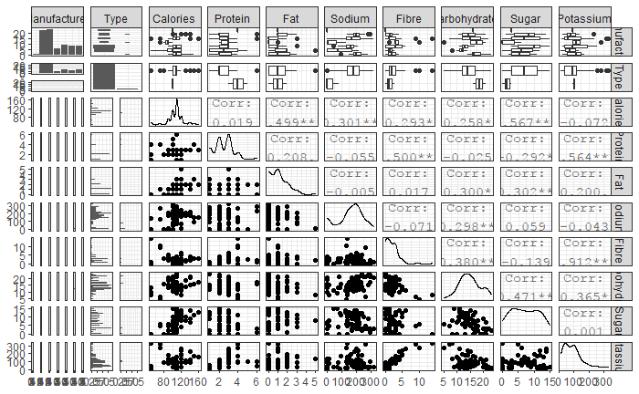

```r
ggpairs(cereals_data,histogram = c(2:11), columns = 2:11 )+theme_bw()
```